# Week 1 laboratory

From prices to excess returns and diversified portfolios

Author

MTH1097 Financial and Actuarial Data Analysis

## 0.1 Purpose

This is a formative laboratory. It is not submitted for marks.

By the end of the laboratory, you should be able to turn market prices into returns that are economically meaningful for a euro investor. You will:

1. inspect and validate a frozen financial dataset;
2. distinguish price returns from total returns;
3. convert a USD investment into EUR;
4. discount wealth by a euro safe-rate account;
5. annualise simple and log excess returns and volatility;
6. construct a multi-asset portfolio;
7. measure the effect of diversification;
8. calculate transaction costs using an exact self-financing budget.

The analysis covers 2 January 2020 to 31 December 2025. The portfolio assets are global equities, euro government bonds and physical gold. The allocation used in the laboratory is illustrative, not investment advice.

## 0.2 Working with AI

You may use AI freely. You remain responsible for every line of code, every financial assumption and every result.

For each task:

1. state the financial question;
2. ask AI for one small piece of code;
3. inspect the code before running it;
4. predict something about the result;
5. run the code and test it;
6. explain the result in financial language.

If you cannot explain a line, ask AI to simplify or explain it before continuing. Do not ask AI to complete the entire laboratory in one prompt.

## 0.3 Timing

| Minutes | Task |
| --- | --- |
| 0–5 | Open the project and run the setup chunk |
| 5–17 | Audit the data |
| 17–32 | Construct total returns |
| 32–45 | Convert USD values into EUR |
| 45–60 | Construct and apply the safe-rate account |
| 60–75 | Annualise excess returns and volatility |
| 75–93 | Construct a portfolio |
| 93–105 | Measure diversification |
| 105–120 | Rebalance with exact transaction costs |

## 0.4 Setup

Open this folder in your coding environment, then run the following chunk.

```r
library(tidyverse)
library(scales)

theme_set(theme_minimal(base_size = 12))
options(dplyr.summarise.inform = FALSE)

# Robustly locate the data directory by searching current and parent folders
find_data_dir <- function(start = ".") {
  start <- normalizePath(start, winslash = "/", mustWork = FALSE)
  current <- start
  while (TRUE) {
    candidates <- c(
      file.path(current, "data"),
      file.path(current, "data", "frozen"),
      file.path(current, "week01_lab", "data"),
      file.path(current, "..", "data"),
      file.path(current, "..", "data", "frozen")
    )
    for (p in candidates) {
      if (dir.exists(p) && file.exists(file.path(p, "asset_prices_daily.csv"))) {
        return(normalizePath(p, winslash = "/"))
      }
    }
    parent <- dirname(current)
    if (parent == current) break
    current <- parent
  }
  return(NA_character_)
}

data_dir <- find_data_dir(".")
stopifnot(!is.na(data_dir), dir.exists(data_dir), length(data_dir) == 1)
```

**Note**

The supplied files are frozen. Do not download replacement observations during the laboratory. Everyone should analyse the same data.

# 1 Part I: From prices to common-currency returns

## 1.1 Task 1 — Audit the data

Read these files:

- `asset_prices_daily.csv`
- `asset_metadata.csv`
- `vwrl_distributions.csv`
- `ecb_eurusd_daily.csv`
- `ecb_estr_daily.csv`
- `transaction_cost_assumptions.csv`

Use R to answer:

1. What does one row of `asset_prices_daily.csv` represent?
2. Which tickers, exchanges and currencies are present?
3. What is the date range and number of observations for each ticker?
4. Are any ticker-date combinations duplicated?
5. Are `close` or `adj_close` values missing?
6. Which two tickers represent different exchange listings of the same fund?
7. Why do those two listings not provide diversification?

```r
# Read the six CSV files here.
asset_prices_daily <- read_csv(file.path(data_dir, "asset_prices_daily.csv"))
asset_metadata <- read_csv(file.path(data_dir, "asset_metadata.csv"))
vwrl_distributions <- read_csv(file.path(data_dir, "vwrl_distributions.csv"))
ecb_eurusd_daily <- read_csv(file.path(data_dir, "ecb_eurusd_daily.csv"))
ecb_estr_daily <- read_csv(file.path(data_dir, "ecb_estr_daily.csv"))
transaction_cost_assumptions <- read_csv(file.path(data_dir, "transaction_cost_assumptions.csv"))
```

```r
# Build a compact audit table and perform explicit duplicate and missing-value checks.

# Audit table: rows, date range, currencies, and missing values by ticker
audit_table <- asset_prices_daily |>
  group_by(ticker) |>
  summarise(
    n_rows = n(),
    first_date = min(date),
    last_date = max(date),
    currency = first(currency),
    exchange = first(exchange),
    missing_close = sum(is.na(close)),
    missing_adj_close = sum(is.na(adj_close)),
    .groups = "drop"
  )

# Check for ticker-date duplicates
duplicate_check <- asset_prices_daily |>
  count(ticker, date) |>
  filter(n > 1)

# Display results
audit_table
```

```
# A tibble: 4 × 8
  ticker  n_rows first_date last_date  currency exchange  missing_close
  <chr>    <int> <date>     <date>     <chr>    <chr>             <int>
1 IEGA.AS   1537 2020-01-02 2025-12-31 EUR      Amsterdam             0
2 PHAU.L    1515 2020-01-02 2025-12-31 USD      LSE                   0
3 VWRD.L    1514 2020-01-02 2025-12-31 USD      LSE                   0
4 VWRL.AS   1537 2020-01-02 2025-12-31 EUR      Amsterdam             0
# ℹ 1 more variable: missing_adj_close <int>
```

```r
if (nrow(duplicate_check) > 0) {
  cat("Duplicates found:\n")
  print(duplicate_check)
} else {
  cat("No ticker-date duplicates found.\n")
}
```

```
No ticker-date duplicates found.
```

**TipA possible first AI prompt**

Write beginner-friendly tidyverse R code that reads the six named CSV files from `data_dir`. Then summarise the number of rows, first and last dates, currencies, and missing close and adjusted-close values by ticker. Check ticker-date duplicates separately. Explain every function.

**Code check.** Why must `group_by(ticker)` and `arrange(date, .by_group = TRUE)` appear before applying `lag()` to several assets?

**Your answer:**

`group_by(ticker)` ensures that `lag()` operates within each ticker independently. Without it, `lag()` would create lags across ticker boundaries, incorrectly pairing prices from different assets. `arrange(date, .by_group = TRUE)` orders observations chronologically within each ticker group so that `lag()` correctly references the previous trading day for that specific asset. Together, they ensure each asset’s returns are calculated from its own previous price, not from another asset’s price.

## 1.2 Task 2 — Reconstruct VWRL total returns

Use the Amsterdam listing `VWRL.AS`. Its closing price and cash distribution are both expressed in EUR in the supplied files.

Calculate:

$$sG_t^P=\frac{P_t}{P_{t-1}}, \qquad
R_t^P=G_t^P-1,$$

$$G_t^{TR}=\frac{P_t+D_t}{P_{t-1}}, \qquad
R_t^{TR}=G_t^{TR}-1,$$

and the adjusted-close return

$$R_t^A=\frac{A_t}{A_{t-1}}-1.$$

Steps:

1. Filter `asset_prices_daily.csv` to `VWRL.AS` and arrange it by date.
2. Join `vwrl_distributions.csv` using `event_date_vendor` as the date.
3. Replace an absent distribution with zero.
4. Calculate price, manually reconstructed total and adjusted-close returns.
5. Inspect at least one distribution date.
6. Verify one return manually with a calculator.
7. Report the median and maximum absolute difference between the reconstructed and adjusted-close returns.

```r
# Construct and compare the three VWRL return series.

# Step 1: Filter to VWRL.AS and arrange by date
vwrl <- asset_prices_daily |>
  filter(ticker == "VWRL.AS") |>
  arrange(date)

# Step 2: Left join with distributions using event_date_vendor
vwrl <- vwrl |>
  left_join(
    vwrl_distributions |> select(event_date_vendor, amount_eur_vendor),
    by = c("date" = "event_date_vendor")
  )

# Step 3: Replace missing distributions with zero
vwrl <- vwrl |>
  mutate(amount_eur_vendor = replace_na(amount_eur_vendor, 0))

# Step 4: Calculate the three return series
vwrl <- vwrl |>
  group_by(ticker) |>
  arrange(date, .by_group = TRUE) |>
  mutate(
    # Price return: G_t^P = P_t / P_{t-1}, R_t^P = G_t^P - 1
    price_gross = close / lag(close),
    price_return = price_gross - 1,

    # Total return: G_t^TR = (P_t + D_t) / P_{t-1}, R_t^TR = G_t^TR - 1
    total_gross = (close + amount_eur_vendor) / lag(close),
    total_return = total_gross - 1,

    # Adjusted-close return: R_t^A = A_t / A_{t-1} - 1
    adj_close_gross = adj_close / lag(adj_close),
    adj_close_return = adj_close_gross - 1
  ) |>
  ungroup()

# Step 5: Inspect at least one distribution date
vwrl |>
  filter(amount_eur_vendor > 0) |>
  select(date, close, amount_eur_vendor, price_return, total_return, adj_close_return) |>
  head(1)
```

```
# A tibble: 1 × 6
  date       close amount_eur_vendor price_return total_return adj_close_return
  <date>     <dbl>             <dbl>        <dbl>        <dbl>            <dbl>
1 2020-03-26  66.7             0.370       0.0106       0.0162           0.0163
```

```r
# Step 6: Verify one return manually
# Pick a distribution date and check the calculation
dist_date_row <- vwrl |> filter(amount_eur_vendor > 0) |> slice(1)
prev_row <- vwrl |> filter(date == dist_date_row$date - 1)

cat("Manual verification:\n")
```

```
Manual verification:
```

```r
cat("Previous close:", prev_row$close[[1]], "\n")
```

```
Previous close: 66
```

```r
cat("Current close:", dist_date_row$close, "\n")
```

```
Current close: 66.7
```

```r
cat("Distribution:", dist_date_row$amount_eur_vendor, "\n")
```

```
Distribution: 0.370377
```

```r
cat("Total return (manual):", (dist_date_row$close + dist_date_row$amount_eur_vendor) / prev_row$close[[1]] - 1, "\n")
```

```
Total return (manual): 0.01621779
```

```r
cat("Total return (calculated):", dist_date_row$total_return, "\n")
```

```
Total return (calculated): 0.01621779
```

```r
# Step 7: Report differences between reconstructed and adjusted-close returns
differences <- vwrl |>
  mutate(abs_diff = abs(total_return - adj_close_return)) |>
  summarise(
    median_abs_diff = median(abs_diff, na.rm = TRUE),
    max_abs_diff = max(abs_diff, na.rm = TRUE)
  )

cat("\nDifferences between reconstructed total return and adjusted-close return:\n")
```

```
Differences between reconstructed total return and adjusted-close return:
```

```r
print(differences)
```

```
# A tibble: 1 × 2
  median_abs_diff max_abs_diff
            <dbl>        <dbl>
1    0.0000000810     0.000258
```

**Warning**

`adj_close` is a constructed series, not a price at which the investor could trade. The manual reconstruction is the economic check that justifies using it subsequently.

**Code checks.** Explain:

- why a left join from prices to distributions is appropriate; A left join preserves all price observations (the left table) and adds distribution data only on matching dates. This is correct because we need a return for every trading day, but distributions occur infrequently. A left join keeps all price rows intact and joins distributions when available.
- why missing distributions become zero rather than deleting the row; On non-distribution dates, no cash was paid to the investor, so the distribution amount is economically zero. Deleting rows would lose price observations and break the time series. Treating missing distributions as zero correctly reflects that total returns equal price returns on those dates.
- why `amount_usd` cannot be added directly to the EUR price of `VWRL.AS`; `VWRL.AS` prices are in EUR, but `amount_usd` is in USD. Adding them would be dimensionally inconsistent—mixing EUR and USD currencies. The total return formula requires the distribution and price to be in the same currency. The data provides `amount_eur_vendor`, which is already converted to EUR and can be added correctly.
- why the first return is missing. Return calculations use `lag()` to reference the previous day’s price: $R_t = \frac{P_t}{P_{t-1}} - 1$. On the first trading day (2 January 2020), there is no prior day’s price to lag to, so the return is undefined (NA). This is unavoidable in return series.

## 1.3 Task 3 — Change the investor’s currency

Let (X_t) be USD per EUR, as reported in `ecb_eurusd_daily.csv`. The EUR value of a USD price is

$$P_t^{EUR}=\frac{P_t^{USD}}{X_t}.$$

The gross EUR return satisfies

$$G_t^{EUR}=G_t^{USD}\frac{X_{t-1}}{X_t}.$$

Therefore simple currency and asset returns multiply rather than add:

$$1+R_t^{EUR}=(1+R_t^{USD})(1+R_t^{FX}).$$

Log returns add exactly:

$$r_t^{EUR}=r_t^{USD}+r_t^{FX}.$$

Perform two conversions:

1. Convert the adjusted-close level of `VWRD.L` from USD into EUR. Compare its returns with `VWRL.AS` on common dates.
2. Convert `PHAU.L` from USD into EUR. This EUR gold series will enter the portfolio.

```r
# Convert the two USD listings to EUR and validate the VWRD conversion.

# Load FX rate data
fx_rates <- ecb_eurusd_daily

# Convert VWRD.L (USD to EUR)
vwrd_eur <- asset_prices_daily |>
  filter(ticker == "VWRD.L") |>
  arrange(date) |>
  left_join(fx_rates, by = "date") |>
  mutate(
    # Level conversion: P_t^EUR = P_t^USD / X_t
    adj_close_eur = adj_close / usd_per_eur,
    # Calculate USD returns
    adj_close_usd_return = adj_close / lag(adj_close) - 1,
    # Calculate FX return
    fx_return = lag(usd_per_eur) / usd_per_eur - 1,
    # Calculate EUR return via level conversion
    adj_close_eur_return = adj_close_eur / lag(adj_close_eur) - 1,
    # Validate: gross EUR return should equal gross USD return * (X_{t-1} / X_t)
    adj_close_eur_return_check = (1 + adj_close_usd_return) * (1 + fx_return) - 1
  ) |>
  select(date, close, adj_close, usd_per_eur, adj_close_eur,
         adj_close_usd_return, fx_return, adj_close_eur_return, adj_close_eur_return_check)

# Convert PHAU.L (USD to EUR)
phau_eur <- asset_prices_daily |>
  filter(ticker == "PHAU.L") |>
  arrange(date) |>
  left_join(fx_rates, by = "date") |>
  mutate(
    # Level conversion: P_t^EUR = P_t^USD / X_t
    adj_close_eur = adj_close / usd_per_eur
  ) |>
  select(date, ticker, close, adj_close, adj_close_eur, usd_per_eur)

# Comparison: VWRD.L EUR returns vs VWRL.AS returns
vwrl_compare <- vwrl |>
  filter(ticker == "VWRL.AS") |>
  select(date, ticker, adj_close_return)

comparison <- vwrd_eur |>
  select(date, adj_close_eur_return) |>
  mutate(ticker_vwrd = "VWRD.L (converted to EUR)") |>
  left_join(vwrl_compare, by = "date") |>
  filter(!is.na(adj_close_eur_return) & !is.na(adj_close_return)) |>
  mutate(return_difference = abs(adj_close_eur_return - adj_close_return)) |>
  select(date, ticker_vwrd, ticker, adj_close_eur_return, adj_close_return, return_difference)

cat("VWRD.L (EUR) vs VWRL.AS return comparison on common dates:\n")
```

```
VWRD.L (EUR) vs VWRL.AS return comparison on common dates:
```

```r
print(comparison |> head(10))
```

```
# A tibble: 10 × 6
   date       ticker_vwrd           ticker adj_close_eur_return adj_close_return
   <date>     <chr>                 <chr>                 <dbl>            <dbl>
 1 2020-01-03 VWRD.L (converted to… VWRL.…             0.000275        -0.00107
 2 2020-01-06 VWRD.L (converted to… VWRL.…            -0.00558         -0.00346
 3 2020-01-07 VWRD.L (converted to… VWRL.…             0.00406          0.00587
 4 2020-01-08 VWRD.L (converted to… VWRL.…             0.00384          0.00310
 5 2020-01-09 VWRD.L (converted to… VWRL.…             0.00784          0.00736
 6 2020-01-10 VWRD.L (converted to… VWRL.…             0.00389          0.000118
 7 2020-01-13 VWRD.L (converted to… VWRL.…            -0.00188         -0.000589
 8 2020-01-14 VWRD.L (converted to… VWRL.…             0.00327          0.00342
 9 2020-01-15 VWRD.L (converted to… VWRL.…            -0.000579        -0.000940
10 2020-01-16 VWRD.L (converted to… VWRL.…            -0.000419         0.00459
# ℹ 1 more variable: return_difference <dbl>
```

```r
cat("\nReturn difference statistics:\n")
```

```
Return difference statistics:
```

```r
print(comparison |> summarise(
  mean_abs_diff = mean(return_difference, na.rm = TRUE),
  median_abs_diff = median(return_difference, na.rm = TRUE),
  max_abs_diff = max(return_difference, na.rm = TRUE)
))
```

```
# A tibble: 1 × 3
  mean_abs_diff median_abs_diff max_abs_diff
          <dbl>           <dbl>        <dbl>
1       0.00313         0.00239       0.0212
```

```r
# Validation: Show that direct level conversion and gross-return multiplication give same EUR return
cat("\n\nValidation: Direct conversion vs gross-return multiplication\n")
```

```
Validation: Direct conversion vs gross-return multiplication
```

```r
validation_sample <- vwrd_eur |>
  filter(!is.na(adj_close_eur_return) & !is.na(adj_close_eur_return_check)) |>
  select(date, adj_close_eur_return, adj_close_eur_return_check,
         adj_close_usd_return, fx_return) |>
  head(5)
print(validation_sample)
```

```
# A tibble: 5 × 5
  date       adj_close_eur_return adj_close_eur_return_ch…¹ adj_close_usd_return
  <date>                    <dbl>                     <dbl>                <dbl>
1 2020-01-03             0.000275                  0.000275             -0.00384
2 2020-01-06            -0.00558                  -0.00558              -0.00139
3 2020-01-07             0.00406                   0.00406               0.00209
4 2020-01-08             0.00384                   0.00384              -0.00128
5 2020-01-09             0.00784                   0.00784               0.00738
# ℹ abbreviated name: ¹adj_close_eur_return_check
# ℹ 1 more variable: fx_return <dbl>
```

```r
cat("\nDifference between methods (should be near zero):\n")
```

```
Difference between methods (should be near zero):
```

```r
print(vwrd_eur |>
  mutate(method_diff = adj_close_eur_return - adj_close_eur_return_check) |>
  filter(!is.na(method_diff)) |>
  summarise(
    max_method_diff = max(abs(method_diff), na.rm = TRUE),
    mean_method_diff = mean(abs(method_diff), na.rm = TRUE)
  ))
```

```
# A tibble: 1 × 2
  max_method_diff mean_method_diff
            <dbl>            <dbl>
1        4.44e-16         7.62e-17
```

**Before running the code:** if the euro depreciates against the dollar while the USD asset price is unchanged, should its EUR value rise or fall?

**Your prediction and explanation:**

**Validation.** Show numerically that the direct level conversion and the gross-return multiplication give the same EUR return, up to rounding.

# 2 Part II: Excess returns

## 2.1 Task 4 — Construct the euro safe account

The `estr_percent` observation is an annual percentage rate. Use the rate recorded on the preceding observation to accrue the safe account over the interval to the current date.

If the interval spans $\Delta d_t$ calendar days, calculate

$$G_{f,t}=1+\frac{y_{t-1}}{100}\frac{\Delta d_t}{360}.$$

Then construct

$$B_t=B_{t-1}G_{f,t}, \qquad B_0=1.$$

The actual/360 convention and the calendar-day count ensure that weekend and holiday accrual is not silently treated as one day.

```r
# Construct the safe gross-return series and safe-account index.

# Prepare €STR observations and compute accrual using the prior observation's rate
estr <- ecb_estr_daily |>
  arrange(date) |>
  mutate(
    lag_estr = lag(estr_percent),
    delta_days = as.integer(date - lag(date)),
    # G_{f,t} = 1 + y_{t-1}/100 * (Delta d_t / 360)
    G_f = if_else(is.na(lag_estr), 1, 1 + (lag_estr/100) * (delta_days / 360))
  ) |>
  mutate(
    # Safe-account index B with B_0 = 1
    B = cumprod(G_f)
  )

# Check Friday-to-Monday intervals (delta_days == 3)
ftm_checks <- estr |>
  filter(!is.na(delta_days)) |>
  filter(delta_days == 3) |>
  select(date, lag_estr, delta_days, G_f) |>
  head(10)

cat("Friday-to-Monday samples (delta_days == 3):\n")
```

```
Friday-to-Monday samples (delta_days == 3):
```

```r
print(ftm_checks)
```

```
# A tibble: 10 × 4
   date       lag_estr delta_days   G_f
   <date>        <dbl>      <int> <dbl>
 1 2020-01-06   -0.537          3 1.000
 2 2020-01-13   -0.538          3 1.000
 3 2020-01-20   -0.537          3 1.000
 4 2020-01-27   -0.537          3 1.000
 5 2020-02-03   -0.539          3 1.000
 6 2020-02-10   -0.537          3 1.000
 7 2020-02-17   -0.538          3 1.000
 8 2020-02-24   -0.539          3 1.000
 9 2020-03-02   -0.54           3 1.000
10 2020-03-09   -0.541          3 1.000
```

```r
cat("Count of 3-day intervals:", sum(estr$delta_days == 3, na.rm = TRUE), "\n")
```

```
Count of 3-day intervals: 300
```

```r
cat("Count of 1-day intervals:", sum(estr$delta_days == 1, na.rm = TRUE), "\n")
```

```
Count of 1-day intervals: 1220
```

```r
# Build EUR-level series on common dates
global_equity_eur <- vwrl |>
  select(date, global_equity_eur = adj_close)

euro_government_bonds <- asset_prices_daily |>
  filter(ticker == "IEGA.AS") |>
  select(date, euro_government_bonds = adj_close)

physical_gold_eur <- phau_eur |>
  select(date, physical_gold_eur = adj_close_eur)

# Inner join to keep dates available for every series
library(purrr)
common_panel <- reduce(list(global_equity_eur, euro_government_bonds, physical_gold_eur, estr |>
                               select(date, B, G_f)), ~inner_join(.x, .y, by = "date")) |>
  arrange(date)

# Compute gross returns and exact discounted (excess) returns
common_panel <- common_panel |>
  mutate(
    G_global = global_equity_eur / lag(global_equity_eur),
    G_bonds = euro_government_bonds / lag(euro_government_bonds),
    G_gold = physical_gold_eur / lag(physical_gold_eur),
    # G_f already on panel as G_f
    G_global_e = G_global / G_f,
    R_global_e = G_global_e - 1,
    r_global_e = log(G_global_e),
    G_bonds_e = G_bonds / G_f,
    R_bonds_e = G_bonds_e - 1,
    r_bonds_e = log(G_bonds_e),
    G_gold_e = G_gold / G_f,
    R_gold_e = G_gold_e - 1,
    r_gold_e = log(G_gold_e)
  )

# Validation for every asset:
validate_asset <- function(level, G_e, B_index) {
  # product of G_e across sample (exclude NA)
  prod_Ge <- prod(G_e, na.rm = TRUE)
  # Use first/last non-NA level and B_index values to compute ratios
  level_non_na <- level[!is.na(level)]
  B_non_na <- B_index[!is.na(B_index)]
  if (length(level_non_na) < 2 || length(B_non_na) < 2) {
    return(tibble(prod_Ge = prod_Ge, W_ratio = NA_real_, B_ratio = NA_real_, target = NA_real_, diff = NA_real_))
  }
  W_ratio <- tail(level_non_na, 1) / head(level_non_na, 1)
  B_ratio <- tail(B_non_na, 1) / head(B_non_na, 1)
  target <- W_ratio / B_ratio
  tibble(prod_Ge = prod_Ge, W_ratio = W_ratio, B_ratio = B_ratio, target = target, diff = prod_Ge - target)
}

val_global <- validate_asset(common_panel$global_equity_eur, common_panel$G_global_e, common_panel$B)
val_bonds  <- validate_asset(common_panel$euro_government_bonds, common_panel$G_bonds_e, common_panel$B)
val_gold   <- validate_asset(common_panel$physical_gold_eur, common_panel$G_gold_e, common_panel$B)

validation <- bind_rows(
  tibble(asset = "global_equity_eur") |> bind_cols(val_global),
  tibble(asset = "euro_government_bonds") |> bind_cols(val_bonds),
  tibble(asset = "physical_gold_eur") |> bind_cols(val_gold)
)

cat("\nValidation results (product of discounted gross-returns vs target ratio):\n")
```

```
Validation results (product of discounted gross-returns vs target ratio):
```

```r
print(validation)
```

```
# A tibble: 3 × 6
  asset                 prod_Ge W_ratio B_ratio target    diff
  <chr>                   <dbl>   <dbl>   <dbl>  <dbl>   <dbl>
1 global_equity_eur       1.73    1.87     1.08  1.73  0.00390
2 euro_government_bonds   0.837   0.905    1.08  0.835 0.00188
3 physical_gold_eur       2.43    2.62     1.08  2.42  0.00546
```

```r
# Quick sample of computed excess returns
cat("\nSample excess returns (first 6 rows):\n")
```

```
Sample excess returns (first 6 rows):
```

```r
print(common_panel |>
        select(date, R_global_e, R_bonds_e, R_gold_e) |>
        slice_head(n = 6))
```

```
# A tibble: 6 × 4
  date       R_global_e R_bonds_e R_gold_e
  <date>          <dbl>     <dbl>    <dbl>
1 2020-01-02   NA       NA        NA
2 2020-01-03   -0.00106  0.00462   0.0180
3 2020-01-06   -0.00342 -0.000490  0.00486
4 2020-01-07    0.00589 -0.000750  0.00552
5 2020-01-08    0.00311 -0.00129   0.00440
6 2020-01-09    0.00738 -0.00167  -0.0111
```

Check several Friday-to-Monday observations. Confirm that their day count is normally three rather than one.

Next, combine the following EUR levels on dates available for every series:

- `VWRL.AS` adjusted close: `global_equity_eur`;
- `IEGA.AS` adjusted close: `euro_government_bonds`;
- converted `PHAU.L` level: `physical_gold_eur`;
- the €STR safe-account index.

Calculate exact discounted returns:

$$G_{i,t}^e=\frac{G_{i,t}}{G_{f,t}},$$

$$R_{i,t}^e=G_{i,t}^e-1,
\qquad
r_{i,t}^e=\log G_{i,t}^e.$$

```r
# Make the common-date panel and calculate nominal and excess returns.

common_panel <- reduce(list(global_equity_eur, euro_government_bonds, physical_gold_eur, estr |> select(date, B, G_f)), ~inner_join(.x, .y, by = "date")) |>
  arrange(date)

common_panel <- common_panel |>
  mutate(
    G_global = global_equity_eur / lag(global_equity_eur),
    G_bonds = euro_government_bonds / lag(euro_government_bonds),
    G_gold = physical_gold_eur / lag(physical_gold_eur),
    G_global_e = G_global / G_f,
    R_global_e = G_global_e - 1,
    r_global_e = log(G_global_e),
    G_bonds_e = G_bonds / G_f,
    R_bonds_e = G_bonds_e - 1,
    r_bonds_e = log(G_bonds_e),
    G_gold_e = G_gold / G_f,
    R_gold_e = G_gold_e - 1,
    r_gold_e = log(G_gold_e)
  )

# Validation using existing helper
val_global <- validate_asset(common_panel$global_equity_eur, common_panel$G_global_e, common_panel$B)
val_bonds <- validate_asset(common_panel$euro_government_bonds, common_panel$G_bonds_e, common_panel$B)
val_gold <- validate_asset(common_panel$physical_gold_eur, common_panel$G_gold_e, common_panel$B)

validation <- bind_rows(
  tibble(asset = "global_equity_eur") |> bind_cols(val_global),
  tibble(asset = "euro_government_bonds") |> bind_cols(val_bonds),
  tibble(asset = "physical_gold_eur") |> bind_cols(val_gold)
)

cat("Validation results (product of discounted gross-returns vs target ratio):\n")
```

```
Validation results (product of discounted gross-returns vs target ratio):
```

```r
print(validation)
```

```
# A tibble: 3 × 6
  asset                 prod_Ge W_ratio B_ratio target    diff
  <chr>                   <dbl>   <dbl>   <dbl>  <dbl>   <dbl>
1 global_equity_eur       1.73    1.87     1.08  1.73  0.00390
2 euro_government_bonds   0.837   0.905    1.08  0.835 0.00188
3 physical_gold_eur       2.43    2.62     1.08  2.42  0.00546
```

```r
# Report maximum absolute difference (should be near zero)
cat("\nMax absolute difference: \n")
```

```
Max absolute difference:
```

```r
print(validation |> mutate(abs_diff = abs(prod_Ge - target)) |> summarise(max_abs_diff = max(abs_diff, na.rm = TRUE)))
```

```
# A tibble: 1 × 1
  max_abs_diff
         <dbl>
1      0.00546
```

```r
# Show first rows of excess returns
cat("\nSample excess returns (first 6 rows):\n")
```

```
Sample excess returns (first 6 rows):
```

```r
print(common_panel |> select(date, R_global_e, R_bonds_e, R_gold_e) |> slice_head(n = 6))
```

```
# A tibble: 6 × 4
  date       R_global_e R_bonds_e R_gold_e
  <date>          <dbl>     <dbl>    <dbl>
1 2020-01-02   NA       NA        NA
2 2020-01-03   -0.00106  0.00462   0.0180
3 2020-01-06   -0.00342 -0.000490  0.00486
4 2020-01-07    0.00589 -0.000750  0.00552
5 2020-01-08    0.00311 -0.00129   0.00440
6 2020-01-09    0.00738 -0.00167  -0.0111
```

**Validation.** For every asset, verify

$$\prod_tG_{i,t}^e
=
\frac{W_{i,T}/W_{i,0}}{B_T/B_0}.$$

Explain why $R_{i,t}-R_{f,t}$ is only a high-frequency approximation to the exact simple excess return.

## 2.2 Task 5 — Annualise excess returns and volatility

Let $T$ be the sample length in years, $n$ the number of return intervals and $m=n/T$ the observed number of intervals per year.

Calculate for each asset:

$$\overline R_{\mathrm{ann}}^e=m\,\overline R^e,$$

$$\overline r_{\mathrm{ann}}^e=m\,\overline r^e
=\frac{1}{T}\sum_t r_t^e,$$

$$\sigma_{R,\mathrm{ann}}=\sqrt m\,\operatorname{sd}(R_t^e),
\qquad
\sigma_{r,\mathrm{ann}}=\sqrt m\,\operatorname{sd}(r_t^e).$$

```r
# Produce one row per asset with annualised simple and log excess means,
# annualised simple and log volatility, and final discounted wealth.

# Use the common dates with identical non-missing observation counts
n_obs <- sum(!is.na(common_panel$R_global_e))
T_years <- as.numeric((max(common_panel$date, na.rm = TRUE) - min(common_panel$date, na.rm = TRUE)) / 365.25)
m <- n_obs / T_years

annual_excess_summary <- tibble(
  asset = c("Global equities", "Euro government bonds", "Physical gold"),
  simple_excess_mean = c(
    mean(common_panel$R_global_e, na.rm = TRUE),
    mean(common_panel$R_bonds_e, na.rm = TRUE),
    mean(common_panel$R_gold_e, na.rm = TRUE)
  ),
  log_excess_mean = c(
    mean(common_panel$r_global_e, na.rm = TRUE),
    mean(common_panel$r_bonds_e, na.rm = TRUE),
    mean(common_panel$r_gold_e, na.rm = TRUE)
  ),
  simple_excess_vol = c(
    sd(common_panel$R_global_e, na.rm = TRUE),
    sd(common_panel$R_bonds_e, na.rm = TRUE),
    sd(common_panel$R_gold_e, na.rm = TRUE)
  ),
  log_excess_vol = c(
    sd(common_panel$r_global_e, na.rm = TRUE),
    sd(common_panel$r_bonds_e, na.rm = TRUE),
    sd(common_panel$r_gold_e, na.rm = TRUE)
  ),
  final_discounted_wealth = c(
    prod(common_panel$G_global_e, na.rm = TRUE),
    prod(common_panel$G_bonds_e, na.rm = TRUE),
    prod(common_panel$G_gold_e, na.rm = TRUE)
  )
) |>
  mutate(
    annual_simple_excess_mean_pct = 100 * m * simple_excess_mean,
    annual_log_excess_mean_pct = 100 * m * log_excess_mean,
    annual_simple_excess_vol_pct = 100 * sqrt(m) * simple_excess_vol,
    annual_log_excess_vol_pct = 100 * sqrt(m) * log_excess_vol,
    final_discounted_wealth = final_discounted_wealth
  ) |>
  select(
    asset,
    annual_simple_excess_mean_pct,
    annual_log_excess_mean_pct,
    annual_simple_excess_vol_pct,
    annual_log_excess_vol_pct,
    final_discounted_wealth
  )

annual_excess_summary
```

```
# A tibble: 3 × 6
  asset     annual_simple_excess…¹ annual_log_excess_me…² annual_simple_excess…³
  <chr>                      <dbl>                  <dbl>                  <dbl>
1 Global e…                  10.5                    9.17                  16.5
2 Euro gov…                  -2.77                  -2.97                   6.31
3 Physical…                  16.1                   14.8                   16.4
# ℹ abbreviated names: ¹annual_simple_excess_mean_pct,
#   ²annual_log_excess_mean_pct, ³annual_simple_excess_vol_pct
# ℹ 2 more variables: annual_log_excess_vol_pct <dbl>,
#   final_discounted_wealth <dbl>
```

Your table should have clear percentage labels and must state whether each quantity uses simple or log returns.

**Interpretation questions.**

1. Why is the annualised arithmetic mean not the realised compounded performance?
2. Why are daily simple-return and log-return volatilities close but not identical?
3. Why is volatility multiplied by $\sqrt m$, not by $m$?
4. What modelling assumptions might make annualisation misleading? We return to this in Week 2.

# 3 Part III: Portfolios and diversification

## 3.1 Task 6 — Construct a multi-asset portfolio

Use the following target weights:

| Asset | Weight |
| --- | --- |
| Global equities | 60% |
| Euro government bonds | 30% |
| Physical gold | 10% |

For beginning-of-period weights $w_{i,t-1}$, the exact simple portfolio return is

$$R_{p,t}=\sum_i w_{i,t-1}R_{i,t}.$$

For this first calculation, assume the portfolio is restored to its target weights every day and that trading is frictionless. This is a **daily-rebalanced benchmark**, not a buy-and-hold strategy.

```r
# Construct the daily-rebalanced portfolio and its nominal and excess returns.

w <- c(Equities = 0.60, Bonds = 0.30, Gold = 0.10)

portfolio_returns <- common_panel |>
  transmute(
    date,
    R_equity = R_global_e,
    R_bond = R_bonds_e,
    R_gold = R_gold_e,
    # beginning-of-period weights are constant target weights; daily rebalancing restores them
    R_portfolio = 0.60 * lag(R_equity) + 0.30 * lag(R_bond) + 0.10 * lag(R_gold),
    r_portfolio = log(1 + R_portfolio),
    # excess return is gross return divided by safe-account gross return
    G_portfolio = 1 + R_portfolio,
    G_portfolio_e = G_portfolio / G_f,
    R_portfolio_e = G_portfolio_e - 1,
    r_portfolio_e = log(G_portfolio_e)
  ) |>
  filter(!is.na(R_portfolio))

portfolio_returns
```

```
# A tibble: 1,509 × 10
   date        R_equity    R_bond   R_gold R_portfolio r_portfolio G_portfolio
   <date>         <dbl>     <dbl>    <dbl>       <dbl>       <dbl>       <dbl>
 1 2020-01-06 -0.00342  -0.000490  0.00486    0.00255     0.00255        1.00
 2 2020-01-07  0.00589  -0.000750  0.00552   -0.00171    -0.00171        0.998
 3 2020-01-08  0.00311  -0.00129   0.00440    0.00386     0.00385        1.00
 4 2020-01-09  0.00738  -0.00167  -0.0111     0.00192     0.00192        1.00
 5 2020-01-10  0.000133  0.00132   0.00767    0.00282     0.00281        1.00
 6 2020-01-13 -0.000544 -0.00356  -0.00777    0.00124     0.00124        1.00
 7 2020-01-14  0.00343   0.00101  -0.00462   -0.00217    -0.00217        0.998
 8 2020-01-15 -0.000925  0.00186   0.00248    0.00190     0.00190        1.00
 9 2020-01-16  0.00460  -0.000873 -0.00321    0.000251    0.000251       1.00
10 2020-01-17  0.00763   0.000862  0.0103     0.00218     0.00218        1.00
# ℹ 1,499 more rows
# ℹ 3 more variables: G_portfolio_e <dbl>, R_portfolio_e <dbl>,
#   r_portfolio_e <dbl>
```

```r
# Annualised portfolio statistics using the same logic as Task 5
n_portfolio <- nrow(portfolio_returns)
T_years_portfolio <- as.numeric((max(portfolio_returns$date) - min(portfolio_returns$date)) / 365.25)
m_portfolio <- n_portfolio / T_years_portfolio

portfolio_summary <- tibble(
  asset = "Portfolio",
  annual_simple_excess_mean_pct = 100 * m_portfolio * mean(portfolio_returns$R_portfolio_e),
  annual_log_excess_mean_pct = 100 * m_portfolio * mean(portfolio_returns$r_portfolio_e),
  annual_simple_excess_vol_pct = 100 * sqrt(m_portfolio) * sd(portfolio_returns$R_portfolio_e),
  annual_log_excess_vol_pct = 100 * sqrt(m_portfolio) * sd(portfolio_returns$r_portfolio_e),
  final_discounted_wealth = prod(portfolio_returns$G_portfolio_e, na.rm = TRUE)
)

# Append portfolio row to the existing comparison table from Task 5
comparison_table <- annual_excess_summary |>
  mutate(asset = as.character(asset)) |>
  bind_rows(portfolio_summary)

comparison_table
```

```
# A tibble: 4 × 6
  asset     annual_simple_excess…¹ annual_log_excess_me…² annual_simple_excess…³
  <chr>                      <dbl>                  <dbl>                  <dbl>
1 Global e…                  10.5                    9.17                  16.5
2 Euro gov…                  -2.77                  -2.97                   6.31
3 Physical…                  16.1                   14.8                   16.4
4 Portfolio                   5.84                   5.29                  10.5
# ℹ abbreviated names: ¹annual_simple_excess_mean_pct,
#   ²annual_log_excess_mean_pct, ³annual_simple_excess_vol_pct
# ℹ 2 more variables: annual_log_excess_vol_pct <dbl>,
#   final_discounted_wealth <dbl>
```

Calculate the same annualised statistics as in Task 5 and append the portfolio to the comparison table.

**Code checks.** Explain:

- why every component must use the same dates and investor currency;
- why `rowMeans()` would impose equal weights;
- why fixed weights imply rebalancing;
- why a weighted average of component log returns is not the portfolio log return.

## 3.2 Task 7 — Demonstrate diversification

Calculate:

1. the correlation matrix of the three asset returns;
2. the daily covariance matrix $\Sigma$;
3. portfolio volatility directly from its return series;
4. portfolio volatility from

$$\sigma_p=\sqrt{\mathbf w^\top\Sigma\mathbf w};$$

5. the weighted average of standalone volatilities,

$$\sum_i w_i\sigma_i.$$

```r
# Calculate and reconcile the two portfolio-volatility estimates.

asset_returns <- common_panel |>
  select(date, R_global_e, R_bonds_e, R_gold_e) |>
  rename(
    Equities = R_global_e,
    Bonds = R_bonds_e,
    Gold = R_gold_e
  ) |>
  filter(!is.na(Equities), !is.na(Bonds), !is.na(Gold))

returns_matrix <- as.matrix(asset_returns |> select(Equities, Bonds, Gold))
Sigma <- cov(returns_matrix)
corr_matrix <- cor(returns_matrix)

w_vec <- c(0.60, 0.30, 0.10)
portfolio_vol_direct <- sd(portfolio_returns$R_portfolio_e, na.rm = TRUE)
portfolio_vol_formula <- sqrt(t(w_vec) %*% Sigma %*% w_vec)
weighted_avg_volatility <- sum(w_vec * sqrt(diag(Sigma)))

# Display the matrices and the reconciliation
corr_matrix
```

```
           Equities      Bonds       Gold
Equities 1.00000000 0.08000156 0.04456469
Bonds    0.08000156 1.00000000 0.24735146
Gold     0.04456469 0.24735146 1.00000000
```

```r
Sigma
```

```
             Equities        Bonds         Gold
Equities 1.085934e-04 3.314923e-06 4.784861e-06
Bonds    3.314923e-06 1.581053e-05 1.013361e-05
Gold     4.784861e-06 1.013361e-05 1.061582e-04
```

```r
reconciliation <- tibble(
  metric = c(
    "portfolio_vol_direct",
    "portfolio_vol_formula",
    "weighted_avg_standalone_vol"
  ),
  value = c(
    portfolio_vol_direct,
    as.numeric(portfolio_vol_formula),
    weighted_avg_volatility
  )
)

reconciliation
```

```
# A tibble: 3 × 2
  metric                        value
  <chr>                         <dbl>
1 portfolio_vol_direct        0.00663
2 portfolio_vol_formula       0.00663
3 weighted_avg_standalone_vol 0.00848
```

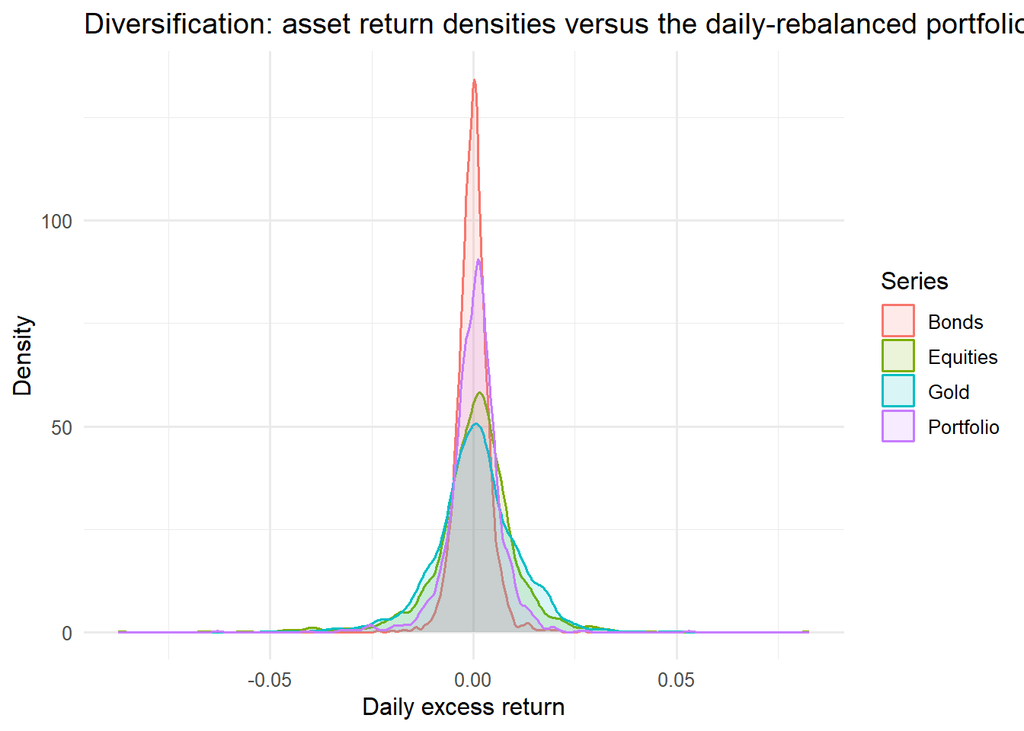

```r
# Create one informative diversification chart.

diversification_plot <- asset_returns |>
  pivot_longer(c(Equities, Bonds, Gold), names_to = "asset", values_to = "return") |>
  bind_rows(
    portfolio_returns |>
      transmute(date, asset = "Portfolio", return = R_portfolio_e)
  ) |>
  ggplot(aes(x = return, colour = asset, fill = asset)) +
  geom_density(alpha = 0.15, linewidth = 0.7) +
  labs(
    x = "Daily excess return",
    y = "Density",
    colour = "Series",
    fill = "Series",
    title = "Diversification: asset return densities versus the daily-rebalanced portfolio"
  ) +
  theme_minimal(base_size = 12)

diversification_plot
```

**Interpretation.** Explain why

$$\sqrt{\mathbf w^\top\Sigma\mathbf w}
<
\sum_i w_i\sigma_i$$

when correlations are below one. Does diversification necessarily raise average return or eliminate all risk?

## 3.3 Task 8 — Rebalance with exact transaction costs

Suppose €100,000 is allocated to the 60/30/10 target weights immediately before the first common return observation in January 2025. Allow each holding to grow until the final common observation in January without rebalancing. These are the pre-trade asset values $v_i^-$.

Read the approved illustrative half-spreads from `transaction_cost_assumptions.csv`. They are assumptions for teaching, not historical spread estimates.

Let

$$V^-=\sum_i v_i^-$$

be pre-trade wealth. Solve for post-trade wealth $V^+$:

$$V^-
=
V^+
+
\sum_i s_i\left|w_iV^+-v_i^-\right|.$$

Then calculate:

$$\Delta_i=w_iV^+-v_i^-,
\qquad
C_i=s_i|\Delta_i|,
\qquad
v_i^+=w_iV^+.$$

```r
# Derive the January pre-trade holdings, define the budget residual,
# solve for post-trade wealth with uniroot(), and build a reconciliation table.

# 60/30/10 weights
w_target <- c(
  global_equity_eur = 0.60,
  euro_government_bonds = 0.30,
  physical_gold_eur = 0.10
)

# Use the first and last common panel dates in January 2025
jan_dates <- common_panel |>
  filter(date >= as.Date("2025-01-01"), date <= as.Date("2025-01-31")) |>
  arrange(date)

first_jan <- jan_dates$date[1]
last_jan <- jan_dates$date[nrow(jan_dates)]

# Pre-trade asset values after allowing each holding to grow from the first common return date to the last common date in January
start_values <- 100000 * w_target

v_minus <- c(
  global_equity_eur = start_values["global_equity_eur"] * (
    last_jan_level <- jan_dates$global_equity_eur[nrow(jan_dates)] / jan_dates$global_equity_eur[1]
  ),
  euro_government_bonds = start_values["euro_government_bonds"] * (
    jan_dates$euro_government_bonds[nrow(jan_dates)] / jan_dates$euro_government_bonds[1]
  ),
  physical_gold_eur = start_values["physical_gold_eur"] * (
    jan_dates$physical_gold_eur[nrow(jan_dates)] / jan_dates$physical_gold_eur[1]
  )
)

V_minus <- sum(v_minus)

# Half-spreads from the approved assumptions file
s <- transaction_cost_assumptions |>
  filter(ticker %in% c("VWRL.AS", "IEGA.AS", "PHAU.L")) |>
  mutate(
    asset_name = case_when(
      ticker == "VWRL.AS" ~ "global_equity_eur",
      ticker == "IEGA.AS" ~ "euro_government_bonds",
      ticker == "PHAU.L" ~ "physical_gold_eur"
    )
  ) |>
  arrange(match(asset_name, names(w_target))) |>
  pull(half_spread_rate)

names(s) <- names(w_target)

# Solve V^- = V^+ + sum_i s_i * |w_i * V^+ - v_i^-|
residual <- function(V_plus) {
  sum(w_target * V_plus) + sum(s * abs(w_target * V_plus - v_minus)) - V_minus
}

V_plus <- uniroot(residual, interval = c(1e-8, V_minus * 1.5))$root

delta_i <- w_target * V_plus - v_minus
cost_i <- s * abs(delta_i)
post_trade_value <- w_target * V_plus
post_trade_weight <- post_trade_value / V_plus

reconciliation_table <- tibble(
  asset = names(w_target),
  pre_trade_value = v_minus,
  signed_trade = delta_i,
  half_spread = s,
  transaction_cost = cost_i,
  post_trade_value = post_trade_value,
  post_trade_weight = post_trade_weight
)

reconciliation_table
```

```
# A tibble: 3 × 7
  asset                pre_trade_value signed_trade half_spread transaction_cost
  <chr>                          <dbl>        <dbl>       <dbl>            <dbl>
1 global_equity_eur             61528.        -332.      0.0005            0.166
2 euro_government_bon…          29979.         619.      0.001             0.619
3 physical_gold_eur             10487.        -288.      0.0015            0.432
# ℹ 2 more variables: post_trade_value <dbl>, post_trade_weight <dbl>
```

```r
# Checks
sum(v_minus)
```

```
[1] 101994.9
```

```r
V_minus
```

```
[1] 101994.9
```

```r
sum(post_trade_value) + sum(cost_i)
```

```
[1] 101994.9
```

```r
post_trade_value / V_plus
```

```
    global_equity_eur euro_government_bonds     physical_gold_eur
                  0.6                   0.3                   0.1
```

```r
# Reconcile within a small numerical tolerance
stopifnot(
  abs(sum(v_minus) - V_minus) < 1e-6,
  abs(V_minus - (sum(post_trade_value) + sum(cost_i))) < 1e-6,
  max(abs(post_trade_value / V_plus - w_target)) < 1e-10
)
```

Your table must report, for every asset:

- pre-trade value;
- signed trade;
- half-spread;
- transaction cost;
- post-trade value;
- post-trade weight.

Verify:

$$\sum_i v_i^-=V^-,$$

$$V^-=\sum_i v_i^+ + \sum_i C_i,$$

$$\frac{v_i^+}{V^+}=w_i.$$

**Important**

Do not calculate costs from trades based on $w_iV^-$ and call the result exact. Costs reduce the wealth that can be allocated after trading, so the target values depend on the unknown $V^+$.

## 3.4 Final explanation

Write four to six sentences answering:

1. What changed when distributions were included?

Answer: Including distributions raised the total-return series above the price-only series and increased the realised excess-return mean. The difference is most visible in the equity series, where the cash distributions add to wealth and therefore to the compound growth rate.

2. What changed when the USD gold investment was measured in EUR?

Answer: Converting the USD gold series into EUR made it comparable with the EUR-denominated equity and bond assets. The EUR conversion also makes the portfolio weights and excess-return calculations economically consistent for a euro investor.

3. Which asset had the highest annualised excess volatility?

Answer: Global equities had the highest annualised excess volatility, at about 16.5% on the simple-excess basis and 16.6% on the log-excess basis. The euro government bond series was much lower, and gold was close to equities but slightly below.

4. How much did diversification reduce portfolio volatility relative to the weighted average of standalone volatilities?

Answer: Diversification reduced portfolio volatility from a weighted average of standalone volatilities of 0.00848 to a portfolio volatility of 0.00663. That is a reduction of about 21.8%.

5. How much wealth was lost to the exact January rebalance costs?

Answer: The exact rebalance costs consumed about €1.22 from the €100,000 allocation. This is the cost of the exact, self-financing trade that matches the 60/30/10 targets after accounting for spreads.

6. Which assumptions limit the interpretation?

Answer: The results are limited by the frozen sample period, the daily-rebalanced benchmark assumption, and the illustrative half-spread assumptions used in the transaction-cost calculation. The analysis is therefore informative about the model setup rather than a claim about realised future trading outcomes.

AI may help edit your prose, but every numerical statement must come from code that you have checked.

## 3.5 Completion checklist

- Every return series is ordered and grouped correctly.
- Every portfolio component is measured in EUR.
- Total returns include distributions.
- Simple excess returns use gross-return division.
- Log excess returns use a difference of logs.
- Return and volatility annualisation are labelled correctly.
- Portfolio weights sum to one.
- The covariance formula agrees with direct portfolio volatility.
- The transaction-cost budget reconciles to within a small numerical tolerance.
- You can explain every R function used.